# R Notebook

```r
library(rpart)
library(rpart.plot)
library(tidyverse)

library(tidyverse)

set.seed(19)
titanic_set <- read_csv('data/titanic_decision_tree_data.csv')
shuffle_index <- sample(1:nrow(titanic_set),  size = nrow(titanic_set)*0.2)

# shuffle the data so class order isn't in order - need this for training/testing split later on
titanic_set <- titanic_set[shuffle_index, ]
```

# question 1

```r
titanic_set <- titanic_set %>%
  select(-c(name, passenger_id, fare, cabin, X1, ticket)) %>%
  drop_na(survived) %>%
  mutate(pclass = as.factor(pclass)) %>%
  mutate(sex = as.factor(sex)) %>%
  mutate(age_status = as.factor(if_else(age <= 16, "child", "adult"))) %>%
  mutate(survived = as.factor(survived)) %>%
  mutate(embarked = as.factor(embarked)) %>%
  na.omit()
```

# question 2

## Have a look at your data and create some plots to ensure you know what you’re working with before you begin. Write a summary of what you have found in your plots. Which variables do you think might be useful to predict whether or not people are going to die? Knowing this before you start is the best way to have a sanity check that your model is doing a good job.

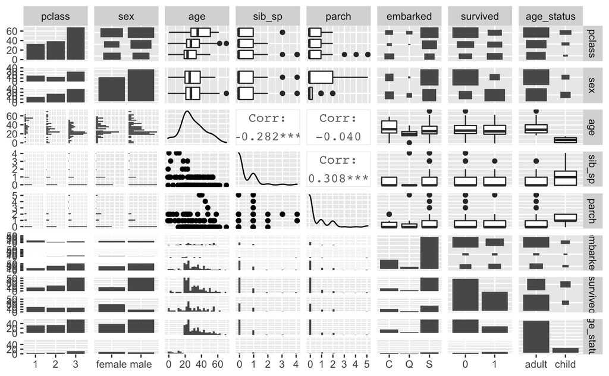

```r
library(GGally)
ggpairs(titanic_set)
```

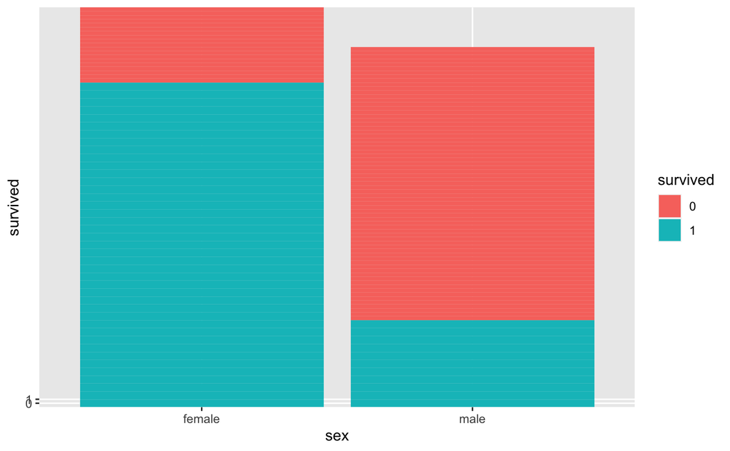

```r
titanic_set %>%
  ggplot()+
  aes(x = sex, y = survived, fill = survived)+
  geom_col()
```

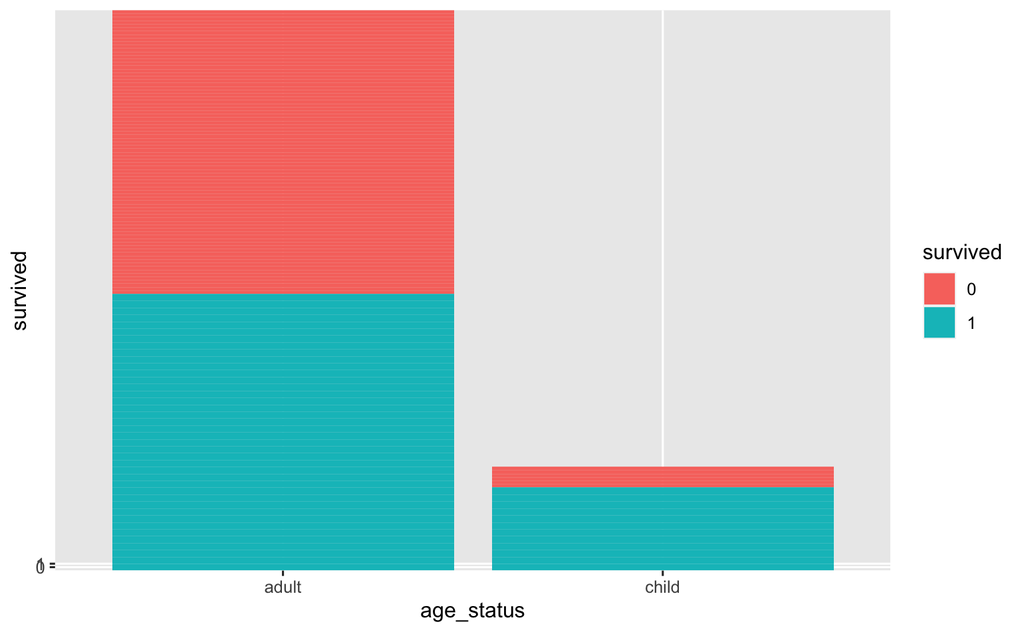

```r
titanic_set %>%
  ggplot()+
  aes(x = age_status, y = survived, fill = survived)+
  geom_col()
```

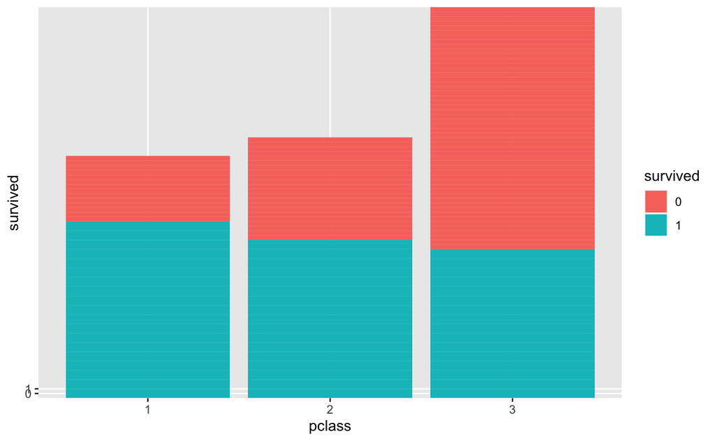

```r
titanic_set %>%
  ggplot()+
  aes(x = pclass, y = survived, fill = survived)+
  geom_col()
```

# question 3

## Now you can start to build your model. Create your testing and training set using an appropriate split. Check you have balanced sets. Write down why you chose the split you did and produce output tables to show whether or not it is balanced.

### testing set

```r
titanic_test  <- slice(titanic_set, shuffle_index)

nrow(titanic_test)
```

```
[1] 30
```

### training set

```r
titanic_train <- slice(titanic_set,  -shuffle_index)

nrow(titanic_train)
```

```
[1] 110
```

```r
titanic_test %>%
  tabyl(survived)
```

```
 survived  n   percent
        0 14 0.4666667
        1 16 0.5333333
```

```r
titanic_train %>%
  tabyl(survived)
```

```
 survived  n   percent
        0 74 0.6727273
        1 36 0.3272727
```

## question 4

### Create your decision tree to try and predict survival probability using an appropriate method, and create a decision tree plot.

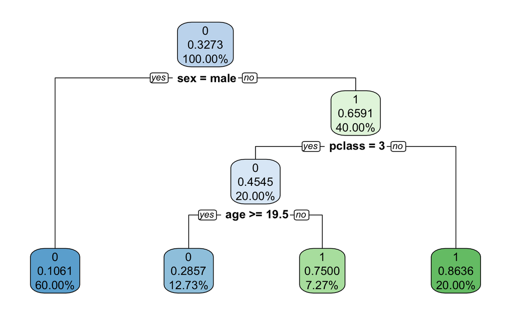

```r
titanic_fit <- rpart(
  formula = survived ~ .,
  data = titanic_train,
  method = 'class'
)

rpart.plot(titanic_fit, yesno = 2, fallen.leaves = TRUE, faclen = 6, digits = 4)
```

## question 5. Write down what this tells you, in detail. What variables are important? What does each node tell you? Who has the highest chance of surviving? Who has the lowest? Provide as much detail as you can.

### answer - it seems to confirm that age and sex and class were likely predictors.

## question 6

### Test and add your predicitons to your data. Create a confusion matrix. Write down in detial what this tells you for this specific dataset.

```r
library(modelr)
titanic_test_pred <- titanic_test %>%
  add_predictions(titanic_fit, type = 'class')
```

```r
rpart.predict(titanic_fit, newdata = titanic_test_pred[1:3,], rules=TRUE)
```

| because | sex | is | female | & | pclass | is | 1 or 2 |
| --- | --- | --- | --- | --- | --- | --- | --- |
| because | sex | is | male |  |  |  |  |
| because | sex | is | male |  |  |  |  |

```
Error in `$<-.data.frame`(`*tmp*`, "rule", value = character(0)) :
  replacement has 0 rows, data has 3
```

```r
library(yardstick)
conf_mat <- titanic_test_pred %>%
              conf_mat(truth = survived, estimate = pred)

conf_mat
```

```
          Truth
Prediction  0  1
         0 11  7
         1  3  9
```

```r
library(caret)

confusionMatrix(titanic_test_pred$pred, titanic_test_pred$survived)
```

```
Confusion Matrix and Statistics

          Reference
Prediction  0  1
         0 11  7
         1  3  9

               Accuracy : 0.6667
                 95% CI : (0.4719, 0.8271)
    No Information Rate : 0.5333
    P-Value [Acc > NIR] : 0.09926

                  Kappa : 0.3421

 Mcnemar's Test P-Value : 0.34278

            Sensitivity : 0.7857
            Specificity : 0.5625
         Pos Pred Value : 0.6111
         Neg Pred Value : 0.7500
             Prevalence : 0.4667
         Detection Rate : 0.3667
   Detection Prevalence : 0.6000
      Balanced Accuracy : 0.6741

       'Positive' Class : 0
```